## Assignment (Coursera: Practical Machine Learning)

### Executive Summary

```r
    Training <- read.csv("pml-training.csv",na.strings=c("", "NA"),sep=",",header=TRUE)
    dim(Training)
```

```
## [1] 19622   160
```

```r
    str(Training[1:7])
```

```
## 'data.frame':    19622 obs. of  7 variables:
##  $ X                   : int  1 2 3 4 5 6 7 8 9 10 ...
##  $ user_name           : Factor w/ 6 levels "adelmo","carlitos",..: 2 2 2 2 2 2 2 2 2 2 ...
##  $ raw_timestamp_part_1: int  1323084231 1323084231 1323084231 1323084232 1323084232 1323084232 1323084232 1323084232 1323084232 1323084232 ...
##  $ raw_timestamp_part_2: int  788290 808298 820366 120339 196328 304277 368296 440390 484323 484434 ...
##  $ cvtd_timestamp      : Factor w/ 20 levels "02/12/2011 13:32",..: 9 9 9 9 9 9 9 9 9 9 ...
##  $ new_window          : Factor w/ 2 levels "no","yes": 1 1 1 1 1 1 1 1 1 1 ...
##  $ num_window          : int  11 11 11 12 12 12 12 12 12 12 ...
```

### Download Training Data

There are 19622 observations across 160 columns in the training data. Some of the columns in this file contain blanks and so our first step is to isolate just those variables that we want to use in the initial training exercise. Some columns contain blanks and so these can be discarded. Columns 1-7 contain respondent and time specific information which is not pertinent to our analysis. In light of possible processing limitations with a model containing close to 20000 observations, I opted to train my model on a subsample of the 19622 observations. Specifically, I opted to sample 7% (or 1 in 14 rows) of the training data as this would yield just under 1500 observations (the actual number of observations in the sample is 1402). This sample is the equivalent of a stratified sample since we draw from the training dataset proportional to the number of observations in each classe variable.

```r
    Training <- Training[, colSums(is.na(Training)) == 0]
    Training <- Training[, 8:dim(Training)[2]]
    mySample <- subset(Training ,c(TRUE, FALSE, FALSE, FALSE, FALSE, FALSE, FALSE, FALSE, FALSE, FALSE, FALSE, FALSE, FALSE, FALSE))
```

### Bar Chart Plot

Let’s take a look at a simple plot of the training data, specifically at the frequency count of the Classe variable since that is the focus of our model. We show the counts for the overall training data and for the 7% sample taken from that data.

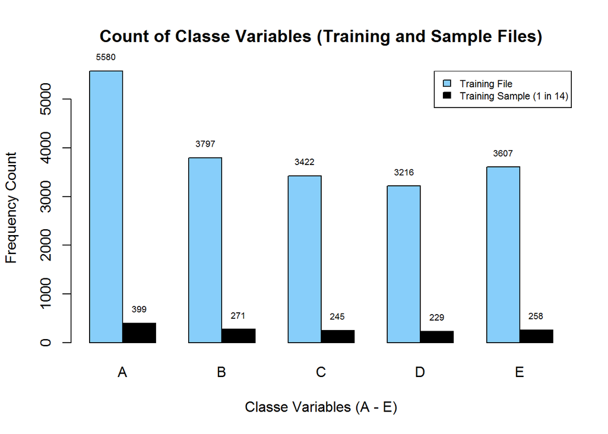

```r
    summary_Trainclasse <- data.frame(summary(Training$classe))
    summary_Sampclasse  <- data.frame(summary(mySample$classe))
    summary_classe <- t(cbind(summary_Trainclasse,summary_Sampclasse))
    bplt <- barplot(as.matrix(summary_classe),
              main="Count of Classe Variables (Training and Sample Files)",
              xlab="Classe Variables (A - E)", ylab="Frequency Count",
              col=c("lightskyblue","black"), beside=TRUE, horiz=FALSE)
    legend("topright", cex=0.7,fill=c("lightskyblue","black"),legend = c("Training File", "Training Sample (1 in 14)"))
    text(x=bplt, y=summary_classe+300, cex=0.6,labels=as.character(summary_classe), xpd=TRUE)
```

### Accuracy and Out-of-sample Error

We note from the results shown below that a random forest model yields 88.5% accuracy in the sample. One might expect that the expected out-of-sample-error will be similar if the variables in the sample are *iid* (independent and identically distributed).

```r
    library(caret)
    modFit <- train(classe ~ ., method="rf", data=mySample, verbose=FALSE)
    modFit$results
```

```
##   mtry  Accuracy     Kappa AccuracySD    KappaSD
## 1    2 0.8729914 0.8388638 0.02141710 0.02701012
## 2   27 0.8852363 0.8544081 0.02108919 0.02666042
## 3   52 0.8746648 0.8410728 0.02000057 0.02514169
```

### Cross Validation

We next use the results from the sample training set to assess accuracy in the overall training set. We report statistics below that include a cross validation table with 95.64% accuracy. We also show statistics by class for each Classe variable (A-E). The balanced accuracy values range from 0.9488 (Classe B) to 0.9854 (Classe A). We can manually compute the accuracy by summing along the main diagonal of the cross validation table and then dividing by the total number of observations in the table. This value is automatically reporting by the confusionMatrix function.

```r
    pred_Training <- predict(modFit, Training)
    confusionMatrix(pred_Training,Training$classe)
```

```
## Confusion Matrix and Statistics
##
##           Reference
## Prediction    A    B    C    D    E
##          A 5502  202    0    4    7
##          B   24 3456  120    3   52
##          C   24  123 3257  109   26
##          D   28    5   43 3081   52
##          E    2   11    2   19 3470
##
## Overall Statistics
##
##                Accuracy : 0.9564
##                  95% CI : (0.9534, 0.9592)
##     No Information Rate : 0.2844
##     P-Value [Acc > NIR] : < 2.2e-16
##
##                   Kappa : 0.9448
##  Mcnemar's Test P-Value : < 2.2e-16
##
## Statistics by Class:
##
##                      Class: A Class: B Class: C Class: D Class: E
## Sensitivity            0.9860   0.9102   0.9518   0.9580   0.9620
## Specificity            0.9848   0.9874   0.9826   0.9922   0.9979
## Pos Pred Value         0.9627   0.9456   0.9203   0.9601   0.9903
## Neg Pred Value         0.9944   0.9786   0.9897   0.9918   0.9915
## Prevalence             0.2844   0.1935   0.1744   0.1639   0.1838
## Detection Rate         0.2804   0.1761   0.1660   0.1570   0.1768
## Detection Prevalence   0.2913   0.1863   0.1804   0.1635   0.1786
## Balanced Accuracy      0.9854   0.9488   0.9672   0.9751   0.9799
```

### Testing Prediction

We now turn to the testing phase of the analysis where we use the results from the training model on the sample data to predict the Classe variable for 20 rows in the testing dataset. We first read in the testing data and extract the relevant non-empty columns while also omitting the seven columns on the left side of the table that contain identifying information that is not pertinent to our prediction analysis. We shown the predicted results below for each of our 20 rows.

```r
    Testing <-  read.csv("pml-testing.csv",na.strings=c("", "NA"),sep=",",header=TRUE)
    Testing <-  Testing[, colSums(is.na(Testing)) == 0]
    Testing <-  Testing[, 8:dim(Testing)[2]-1]
    dim(Testing)
```

```
## [1] 20 53
```

```r
    pred_Test <- data.frame(c(1:20),predict(modFit, Testing))
    colnames(pred_Test) <- c("Problem_ID","Pred_Classe")
    print(pred_Test, row.names=FALSE,justify="center")
```

```
##  Problem_ID Pred_Classe
##           1           B
##           2           A
##           3           B
##           4           A
##           5           A
##           6           E
##           7           D
##           8           B
##           9           A
##          10           A
##          11           B
##          12           C
##          13           B
##          14           A
##          15           E
##          16           E
##          17           A
##          18           B
##          19           A
##          20           B
```

### Conclusion

Fortunately, all 20 predicted Classe variables were found to be accurate when submitted to the Coursera grading system for this course. Additional testing may be needed to further refine the model since the training data is only based on data collected from a small set of individuals. There may be other variables that are currently missing from the training set such as age, gender, fitness level, height, and weight (BMI) that may have a bearing on the exercise outcomes.